# Text_Mining_Reuters

Montse Figueiro

4 de julio de 2016

# Prepocesamiento con el Paquete tm

Vamos a terminar construyengo una matriz de frecuencias,las filas son documentos, las entradas son el numero de veces que ocurren,las columnas son terminos, puedes estudiar classificacion, clustering, detección de temas, representacion grafica, nubes palabras. Los documentos pueden ser novelas, estas matrices son bags of words. es convertirlo en conteo de palabras, con eso destruyes el texto pero puedes hacer ciertas cosas. A veces te quedas con trigramas (trios de palabras) o n-gramas (n palabras consecutivas en el texto) Los trigramas son más utiles en el inglés (muy estructurado), proque todo está hecho para le inglés y el español es un poco diferente.

ngrams

### Matrices de frecuencias:

Pasos a Seguir:

- tokenizacion: parte los textos en palabras. Las palabras que componen un texto, cuales son los separadores posibles, hay un problema por ejemplo espresiones como “estar en los cerros de úbeda” es una expresion como una sola palabra. Nombres propios es una sola palabras “Tribunal de cuentas” es una sola palabra, esto exige tener un buen “ner” named entity recognition, que te permita detectar objetos sujetos cuyo nombre nombres consta de varias palabras. Coges el BOE y quieres saber de que se está hablando. Es más complicado de llo que parece. Mayusculas separadas por un de, hay un diccionario de nombres propios y los encuentra….
- Eliminación palabras comunes (y, la, a), son demasiado comunes y no sirven para los analisis, hay listas por idiomas estas palabras no aportan nada, son frecuentes en todos losdocumentos, TF-IDF es una medida que da peso a los términos que aparecen frecuentemente pero que quieres que aparezcan no en todos los documentos sino también en un subconjunto de documentos. TF- term frecuency IDF- inverse document frequency que aparezca en pocos documentos. quieres dar más peso a uno sobre otro, quieres calibrar que parte es más interesante. cogemos texto, quitamos palabras comunes, tienen el TFIDF más alto.
- Lematización: buscar raíz de las palabras (casa puede ser de casa, de casar) el verbo puede tener mas de 100 formas distintas en español, el españoles muy flexible morfológicamente, una palabra suelta no sabes que raiz tiene “casas”, es casa o casar? hay metodos basados en reglas, snowball. Otros basados en diccionarios, es una busqueda directamente en diccionario, solo que te puede dar varias raices. Basados en máquinas de estados finitos. puedes tener todos los verbos conjugados (esto lo hace el movil cuando predice).

Snowball: lo usan mucho, es un algoritm, te da una coleccion de raíz de palabras, en algunos casos coincide en otros no. Es muy bruto.

Si quieres contar el numero de palabras en un discurso, con Snowball no queda bien, hay palabras que las utilizas con varios generos, no las suma.

- sinónimos: cuando escribes tratas de no repetir palabras, te gustaría deshacer eso, hay que utilizar diccionarios.

Con esto ya tenemos la matriz de frecuencias.

Hoy te casas, hoy es adverbio, te es pronombre y casas puede ser nombre overbo, te calcula las probabilidades de que sea una opcion u otra. Usando modelos de Markov

## Librerias

```r
library(tm)
```

```r
library(RColorBrewer)
library(wordcloud)
```

## Corpus Sources and Readers:

```r
getSources()
```

```
## [1] "DataframeSource" "DirSource"       "URISource"       "VectorSource"
## [5] "XMLSource"       "ZipSource"
```

```r
getReaders()
```

```
##  [1] "readDOC"                 "readPDF"
##  [3] "readPlain"               "readRCV1"
##  [5] "readRCV1asPlain"         "readReut21578XML"
##  [7] "readReut21578XMLasPlain" "readTabular"
##  [9] "readTagged"              "readXML"
```

## Data reuters

```r
data("acq")
acq[[1]]
```

```
## <<PlainTextDocument>>
## Metadata:  15
## Content:  chars: 1287
```

```r
ruta<- system.file("texts", "acq", package = "tm")
ruta
```

```
## [1] "D:/Users/msi/Documents/R/win-library/3.3/tm/texts/acq"
```

```r
reuters <- VCorpus(DirSource(ruta),
                   readerControl = list(reader = readReut21578XMLasPlain))
```

```r
reuters[[1]]
```

```
## <<PlainTextDocument>>
## Metadata:  16
## Content:  chars: 1287
```

### Inspect one document inside Corpus

```r
inspect(reuters[1])
```

```
## <<VCorpus>>
## Metadata:  corpus specific: 0, document level (indexed): 0
## Content:  documents: 1
##
## [[1]]
## <<PlainTextDocument>>
## Metadata:  16
## Content:  chars: 1287
```

```r
str(reuters[1])
```

```
## List of 1
##  $ 10:List of 2
##   ..$ content: chr "Computer Terminal Systems Inc said\nit has completed the sale of 200,000 shares of its common\nstock, and warrants to acquire a"| __truncated__
##   ..$ meta   :List of 16
##   .. ..$ author       : chr(0)
##   .. ..$ datetimestamp: POSIXlt[1:1], format: NA
##   .. ..$ description  : chr ""
##   .. ..$ heading      : chr "COMPUTER TERMINAL SYSTEMS <CPML> COMPLETES SALE"
##   .. ..$ id           : chr "10"
##   .. ..$ language     : chr "en"
##   .. ..$ origin       : chr "Reuters-21578 XML"
##   .. ..$ topics       : chr "YES"
##   .. ..$ lewissplit   : chr "TRAIN"
##   .. ..$ cgisplit     : chr "TRAINING-SET"
##   .. ..$ oldid        : chr "5553"
##   .. ..$ topics_cat   : chr "acq"
##   .. ..$ places       : chr "usa"
##   .. ..$ people       : chr(0)
##   .. ..$ orgs         : chr(0)
##   .. ..$ exchanges    : chr(0)
##   .. ..- attr(*, "class")= chr "TextDocumentMeta"
##   ..- attr(*, "class")= chr [1:2] "PlainTextDocument" "TextDocument"
##  - attr(*, "class")= chr [1:2] "VCorpus" "Corpus"
```

```r
reuters[[1]]$content
```

```
## [1] "Computer Terminal Systems Inc said\nit has completed the sale of 200,000 shares of its common\nstock, and warrants to acquire an additional one mln shares, to\n<Sedio N.V.> of Lugano, Switzerland for 50,000 dlrs.\n    The company said the warrants are exercisable for five\nyears at a purchas…
```

```r
strwrap(reuters[[1]])
```

```
##  [1] "Computer Terminal Systems Inc said it has completed the sale of"
##  [2] "200,000 shares of its common stock, and warrants to acquire an"
##  [3] "additional one mln shares, to <Sedio N.V.> of Lugano, Switzerland"
##  [4] "for 50,000 dlrs.  The company said the warrants are exercisable"
##  [5] "for five years at a purchase price of .125 dlrs per share."
##  [6] "Computer Terminal said Sedio also has the right to buy additional"
##  [7] "shares and increase its total holdings up to 40 pct of the"
##  [8] "Computer Terminal's outstanding common stock under certain"
##  [9] "circumstances involving change of control at the company.  The"
## [10] "company said if the conditions occur the warrants would be"
## [11] "exercisable at a price equal to 75 pct of its common stock's"
## [12] "market price at the time, not to exceed 1.50 dlrs per share."
## [13] "Computer Terminal also said it sold the technolgy rights to its"
## [14] "Dot Matrix impact technology, including any future improvements,"
## [15] "to <Woodco Inc> of Houston, Tex. for 200,000 dlrs. But, it said it"
## [16] "would continue to be the exclusive worldwide licensee of the"
## [17] "technology for Woodco.  The company said the moves were part of"
## [18] "its reorganization plan and would help pay current operation costs"
## [19] "and ensure product delivery.  Computer Terminal makes computer"
## [20] "generated labels, forms, tags and ticket printers and terminals."
## [21] "Reuter"
```

Un Corpus es una lista de documentos; cada documento tiene el texto y un conjunto de metadatos (que no usaremos)

## Transformaciones: tm_map aplica una función a cada documento

```r
reuters <- tm_map(reuters, stripWhitespace) # quitar los espacios en blanco que están de más sobre cada comentarios
reuters <- tm_map(reuters, content_transformer(tolower))#tolower hay que meterla dentro sino no funciona bien,
#pasa todas las palabras a minúsculas
reuters <- tm_map(reuters, removePunctuation)#elimina comas y puntos
reuters <- tm_map(reuters, removeWords, stopwords("en"))#quitamos palabras stopwords,trae una lista, son palabras
#comunes sin importancia en el análisis.
```

```r
reuters[[1]]$content
```

```
## [1] "computer terminal systems inc said   completed  sale  200000 shares   common stock  warrants  acquire  additional one mln shares  sedio nv  lugano switzerland  50000 dlrs  company said  warrants  exercisable  five years   purchase price  125 dlrs per share computer terminal said sedio also  …
```

```r
class(reuters)
```

```
## [1] "VCorpus" "Corpus"
```

## Raíz de las palabras con Snowballc

```r
library(SnowballC)
Snowreuters <- tm_map(reuters[1:10], stemDocument)
Snowreuters[[1]]$content
```

```
## [1] "comput termin system inc said   complet  sale  200000 share   common stock  warrant  acquir  addit one mln share  sedio nv  lugano switzerland  50000 dlrs  compani said  warrant  exercis  five year   purchas price  125 dlrs per share comput termin said sedio also   right  buy addit share  in…
```

## WordCloud reuters

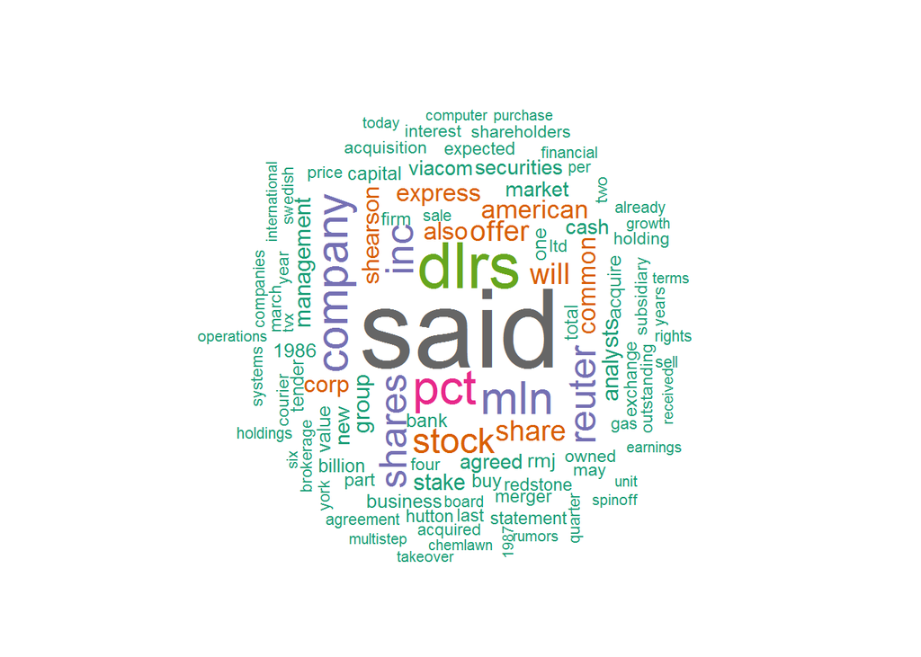

```r
wordcloud(reuters,scale=c(5,0.5),max.words=100,random.order=FALSE,rot.per=0.35,use.r.layout=FALSE,
          colors=brewer.pal(8, "Dark2"))
```

##word matrix

```r
matrix <- DocumentTermMatrix(reuters) #matriz original de frecuencias
findFreqTerms(matrix, 100)#aparecen mas de 100 veces
```

```
## [1] "dlrs" "said"
```

```r
findFreqTerms(matrix,50)#aparecen más de 50 veces
```

```
## [1] "company" "dlrs"    "inc"     "mln"     "pct"     "reuter"  "said"
## [8] "shares"
```

```r
freq.term <- findFreqTerms(matrix,lowfreq = 15)
freq.term
```

```
##  [1] "1986"       "acquire"    "agreed"     "also"       "american"
##  [6] "analysts"   "bank"       "business"   "cash"       "common"
## [11] "company"    "corp"       "dlrs"       "express"    "group"
## [16] "inc"        "management" "market"     "mln"        "new"
## [21] "offer"      "one"        "pct"        "reuter"     "rmj"
## [26] "said"       "securities" "share"      "shares"     "shearson"
## [31] "stake"      "stock"      "value"      "viacom"     "will"
```

### Frecuency Words

```r
matrixreuters <- as.matrix(matrix)
frequency <- colSums(matrixreuters)
frequency <- sort(frequency, decreasing=TRUE)
head(frequency,10)
```

```
##    said    dlrs     pct     mln company     inc  shares  reuter   stock
##     186     100      70      65      63      53      52      50      46
##    will
##      35
```

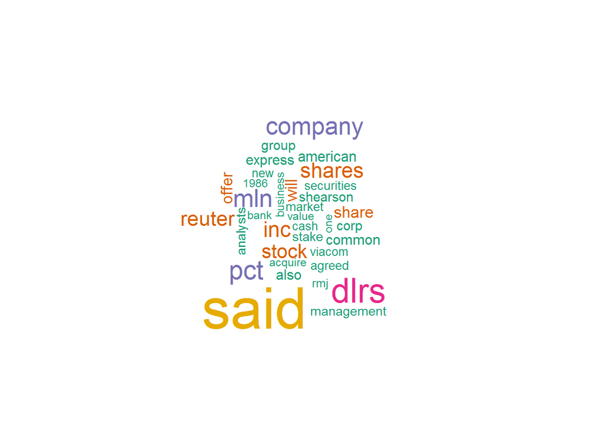

```r
wordcloud(names(frequency), frequency ,min.freq=15, colors=brewer.pal(6, "Dark2"))
```

###Frecuency words removing sparse Terms (this terms apears in a few documents)

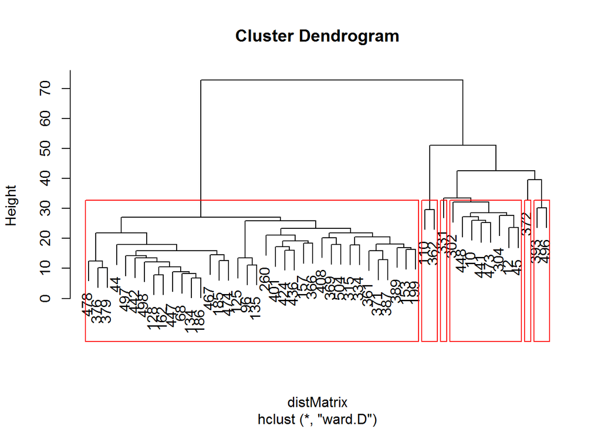

```r
matrixreuters2<- removeSparseTerms(matrix, sparse = 0.95)
m2 <- as.matrix(matrixreuters2)
distMatrix <- dist(scale(m2))
fit <- hclust(distMatrix, method = "ward.D")
plot(fit)
rect.hclust(fit, k = 6) # cut tree into 6 clusters
```

```r
frequency2 <- colSums(m2)
frequency2 <- sort(frequency2, decreasing=TRUE)
head(frequency2,10)
```

```
##    said    dlrs     pct     mln company     inc  shares  reuter   stock
##     186     100      70      65      63      53      52      50      46
##    will
##      35
```

```r
inspect(matrixreuters2[1:10,1:10])
```

```
## <<DocumentTermMatrix (documents: 10, terms: 10)>>
## Non-/sparse entries: 11/89
## Sparsity           : 89%
## Maximal term length: 12
## Weighting          : term frequency (tf)
##
##      Terms
## Docs  125 1985 1986 1987 200 acquire acquired acquisition acquisitions
##   10    1    0    0    0   0       1        0           0            0
##   12    0    0    1    0   0       0        0           0            3
##   44    0    0    0    0   0       0        0           0            0
##   45    0    0    1    0   0       0        1           0            0
##   68    0    0    0    0   0       0        1           0            0
##   96    0    0    0    0   0       0        0           0            0
##   110   0    1    0    0   1       0        0           0            1
##   125   0    0    0    0   0       0        0           0            0
##   128   0    0    0    0   0       0        0           0            0
##   134   0    0    0    0   0       0        0           0            0
##      Terms
## Docs  added
##   10      0
##   12      0
##   44      0
##   45      0
##   68      0
##   96      0
##   110     1
##   125     0
##   128     0
##   134     0
```

## TP-IDF

Normaliza le quita importancia a las palabras que aparecen repetidas en muchos documentos. Le quita peso.

```r
reuters.norm <- weightTfIdf(matrix)
inspect(reuters.norm[1:10,1:10])
```

```
## <<DocumentTermMatrix (documents: 10, terms: 10)>>
## Non-/sparse entries: 2/98
## Sparsity           : 98%
## Maximal term length: 6
## Weighting          : term frequency - inverse document frequency (normalized) (tf-idf)
##
##      Terms
## Docs  05165 0523       100 10000 100000        101 105 1078 110 1100
##   10      0    0 0.0000000     0      0 0.00000000   0    0   0    0
##   12      0    0 0.0000000     0      0 0.00000000   0    0   0    0
##   44      0    0 0.0000000     0      0 0.00000000   0    0   0    0
##   45      0    0 0.0000000     0      0 0.02577103   0    0   0    0
##   68      0    0 0.0000000     0      0 0.00000000   0    0   0    0
##   96      0    0 0.1132648     0      0 0.00000000   0    0   0    0
##   110     0    0 0.0000000     0      0 0.00000000   0    0   0    0
##   125     0    0 0.0000000     0      0 0.00000000   0    0   0    0
##   128     0    0 0.0000000     0      0 0.00000000   0    0   0    0
##   134     0    0 0.0000000     0      0 0.00000000   0    0   0    0
```

```r
reuters.norm.matrix <- as.matrix(reuters.norm)
frequency.norm <- colSums(reuters.norm.matrix)
frequency.norm <- sort(frequency.norm, decreasing=TRUE)
head(frequency.norm,10)
```

```
##    shares   liebert      dlrs       rmj      corp       mln    common
## 0.7854376 0.7054820 0.6901116 0.6870388 0.6542134 0.6469322 0.6450741
##     stock    groupe   esselte
## 0.6286385 0.6270951 0.5759037
```

### La matriz de resultados normalizados la podemos pasar a data.frame

```r
Res <- as.data.frame(inspect(reuters.norm[,c("said","company")]))
```

```
## <<DocumentTermMatrix (documents: 50, terms: 2)>>
## Non-/sparse entries: 27/73
## Sparsity           : 73%
## Maximal term length: 7
## Weighting          : term frequency - inverse document frequency (normalized) (tf-idf)
##
##      Terms
## Docs  said     company
##   10     0 0.027352883
##   12     0 0.011545048
##   44     0 0.000000000
##   45     0 0.016236871
##   68     0 0.000000000
##   96     0 0.000000000
##   110    0 0.012996618
```

[output cut: 43 more lines]

```r
Res[,"company"]
```

```
##  [1] 0.027352883 0.011545048 0.000000000 0.016236871 0.000000000
##  [6] 0.000000000 0.012996618 0.014573257 0.000000000 0.037040362
## [11] 0.000000000 0.015595942 0.029965237 0.000000000 0.000000000
## [16] 0.049387149 0.000000000 0.019325406 0.007377334 0.000000000
## [21] 0.000000000 0.004857752 0.000000000 0.000000000 0.005437117
## [26] 0.009988412 0.014110614 0.013268189 0.020073486 0.040407668
## [31] 0.000000000 0.000000000 0.000000000 0.011696956 0.021949844
## [36] 0.008386497 0.000000000 0.000000000 0.010974922 0.000000000
## [41] 0.000000000 0.024557146 0.000000000 0.025159491 0.018142218
## [46] 0.000000000 0.017545435 0.057976219 0.000000000 0.000000000
```

## Words correlation

```r
findAssocs(matrix, "dlrs", 0.6)
```

```
## $dlrs
##           least          valued          rivals          unless
##            0.84            0.83            0.82            0.82
##            cash        takeover         provide             mln
##            0.81            0.78            0.77            0.74
##         revised             118             150             175
##            0.73            0.72            0.72            0.72
##             195            2275             295            3850
##            0.72            0.72            0.72            0.72
##             475             592         6881800      agreements
##            0.72            0.72            0.72            0.72
##         besides         bidding            bids           chain
##            0.72            0.72            0.72            0.72
##      commitment       confident confidentiality         consist
##            0.72            0.72            0.72            0.72
##      consisting        contains    contribution          dedham
##            0.72            0.72            0.72            0.72
##        disclose       documents           drawn            face
##            0.72            0.72            0.72            0.72
##          fenner          formal          groups            half
##            0.72            0.72            0.72            0.72
##     information            keep           leads         limited
##            0.72            0.72            0.72            0.72
##           lynch       massbased         merrill       monthlong
##            0.72            0.72            0.72            0.72
##           newly        onefifth        operator          pierce
##            0.72            0.72            0.72            0.72
##         portion       purchases         purpose         records
##            0.72            0.72            0.72            0.72
##        redstone       redstones             sec          secret
##            0.72            0.72            0.72            0.72
##        separate             set           smith       submitted
##            0.72            0.72            0.72            0.72
##          sumner         sweeten       sweetened       syndicate
##            0.72            0.72            0.72            0.72
##         theater          toward      underwrite    underwriting
##            0.72            0.72            0.72            0.72
##           vying             war       financing           raise
##            0.72            0.72            0.70            0.70
##       committed             inc           share            4050
##            0.68            0.68            0.68            0.65
##             750          called       committee           eight
##            0.65            0.65            0.65            0.65
##          viacom         viacoms           later        proposed
##            0.65            0.65            0.64            0.64
##             two      contribute           offer        provided
##            0.63            0.62            0.62            0.62
##         earlier
##            0.60
```

```r
findAssocs(matrix, "said", 0.6)
```

```
## $said
##         company        analysts            part           stock
##            0.75            0.74            0.72            0.70
##             316        aftertax        brothers        chairmen
##            0.69            0.69            0.69            0.69
##      considered     contributed         created       divisions
##            0.69            0.69            0.69            0.69
##     eckenfelder          expand         express             got
##            0.69            0.69            0.69            0.69
##          highly        internal            lane           larry
##            0.69            0.69            0.69            0.69
##          lehman            move           place       positions
##            0.69            0.69            0.69            0.69
## prudentialbache        remained          rumors         selling
##            0.69            0.69            0.69            0.69
##           sense          silent         spinoff        unlikely
##            0.69            0.69            0.69            0.69
##          vacant        shearson        american         reflect
##            0.69            0.68            0.66            0.66
##       operating        services           fully          market
##            0.65            0.64            0.63            0.63
##         believe           chief         however         officer
##            0.62            0.62            0.62            0.62
##         several       shearsons      speculated        spinning
##            0.62            0.62            0.62            0.62
##          strong          future            also
##            0.62            0.61            0.60
```

```r
findAssocs(matrix, "pct", 0.6)
```

```
## $pct
##         stake     increased     interests        rights        option
##          0.74          0.69          0.69          0.66          0.63
##          cost           key           126           148          1984
##          0.62          0.62          0.61          0.61          0.61
##           341           400           424           455           494
##          0.61          0.61          0.61          0.61          0.61
##    activities          alfa          alfs      amounted          arms
##          0.61          0.61          0.61          0.61          0.61
##          asea          asts         atlas          back      building
##          0.61          0.61          0.61          0.61          0.61
##        buyers concentrating         copco          core        crowns
##          0.61          0.61          0.61          0.61          0.61
##        defend         diary        empire          erik     expensise
##          0.61          0.61          0.61          0.61          0.61
##      farflung     financier        forced       foreign  forvaltnings
##          0.61          0.61          0.61          0.61          0.61
##        fought      frederik          free        fringe         heart
##          0.61          0.61          0.61          0.61          0.61
##     incentive    industrier     investors    koppabergs         laval
##          0.61          0.61          0.61          0.61          0.61
##          left   londonbased      lundberg       managed         match
##          0.61          0.61          0.61          0.61          0.61
##        matchs         nobel          nobl    originally        ousted
##          0.61          0.61          0.61          0.61          0.61
##       outside        penser     predators       prevent       protect
##          0.61          0.61          0.61          0.61          0.61
##   providentia          raid    restricted        secure       skanska
##          0.61          0.61          0.61          0.61          0.61
##          skbs           skf          skfr          skps         small
##          0.61          0.61          0.61          0.61          0.61
##          smbs         stora       swedens       swedish         taken
##          0.61          0.61          0.61          0.61          0.61
##          thre        tycoon    undertaken          volv         volvo
##          0.61          0.61          0.61          0.61          0.61
##    wallenberg   wallenbergs       wrested   zurichbased        voting
##          0.61          0.61          0.61          0.61          0.60
```

```r
findAssocs(matrix, "mln", 0.6)
```

```
## $mln
## dlrs
## 0.74
```